# Homework #2

Sonya Haan; sonyahaan

## R commands

1. Today’s temperature has a high of 15 and a low of -10 degree fahrenheit. Find the corresponding degress in celsius and storage it in a (single) vector named `cel`. Print the variable.

```r
high = (15 - 32) * (5/9)
low = (-10 - 32) * (5/9)
cel <- c(high, low)
cel
```

```
## [1]  -9.444444 -23.333333
```

2. Create a vector of length 200. The odd entries should be 1 and even entries should be 0. Storage the created in a variable named `vec200` and print.

```r
vec200 = rep(c(1, 0), length.out = 200)
vec200
```

```
##   [1] 1 0 1 0 1 0 1 0 1 0 1 0 1 0 1 0 1 0 1 0 1 0 1 0 1 0 1 0 1 0 1 0 1 0 1
##  [36] 0 1 0 1 0 1 0 1 0 1 0 1 0 1 0 1 0 1 0 1 0 1 0 1 0 1 0 1 0 1 0 1 0 1 0
##  [71] 1 0 1 0 1 0 1 0 1 0 1 0 1 0 1 0 1 0 1 0 1 0 1 0 1 0 1 0 1 0 1 0 1 0 1
## [106] 0 1 0 1 0 1 0 1 0 1 0 1 0 1 0 1 0 1 0 1 0 1 0 1 0 1 0 1 0 1 0 1 0 1 0
## [141] 1 0 1 0 1 0 1 0 1 0 1 0 1 0 1 0 1 0 1 0 1 0 1 0 1 0 1 0 1 0 1 0 1 0 1
## [176] 0 1 0 1 0 1 0 1 0 1 0 1 0 1 0 1 0 1 0 1 0 1 0 1 0
```

3. How many perfect squares are there between 1 and 1001? Storage the answer in a variable named `numPerfect` and print. You may want to look at `?round`.

```r
numPerfect <- floor(sqrt(1001))
numPerfect
```

```
## [1] 31
```

## Cars and mileage

For this part we will use the `mpg` data set, you can access the data by loading the package `ggplot2` into your R session by executing the command `library(ggplot2)`. The `mpg` data includes information about fuel economy of popular car models for the years 1999 and 2008 as collected by the US Environmental Protection Agency. An answer should include a short paragraph of text for the explanation to a (human) reader, together with appropriate R code, outputs, and graphs.

Most exercises are from the ggplot2 book section 2.2.1. You might find it helpful for working on the homework to read through this section. *However, all questions can be solved by using just the basic R graphics functions.*

1. What are the 3 most fuel-efficient models in terms of highway mileage? Storage the data frame (with 3 rows) containing all information of these three cars in a variable named `top3` and print.

First, order the row indices in decreasing order according to `mpg$hwy`. Store the result in a variable `orderedIndices`. Then extract the rows of `mpg` with indices corresponding to the first 3 entries of `orderedIndices`.

```r
library(ggplot2)
orderedIndices <- order(mpg$hwy, decreasing = TRUE)
top3 <- mpg[orderedIndices[1:3], ]
top3
```

```
## # A tibble: 3 x 11
##   manufacturer model  displ  year   cyl trans drv     cty   hwy fl    class
##   <chr>        <chr>  <dbl> <int> <int> <chr> <chr> <int> <int> <chr> <chr>
## 1 volkswagen   jetta    1.9  1999     4 manu~ f        33    44 d     comp~
## 2 volkswagen   new b~   1.9  1999     4 manu~ f        35    44 d     subc~
## 3 volkswagen   new b~   1.9  1999     4 auto~ f        29    41 d     subc~
```

2. How many different compact models are included in this dataset? Storage the answer in a variable named `numCompact` and print.

Extract the rows whose `class` is ‘compact’ and store in a data frame called `compacts`. Find the length of the vector of unique models from the `compacts` data frame.

```r
compacts <- mpg[mpg$class == 'compact', ]
numCompact <- length(unique(compacts$model))
numCompact
```

```
## [1] 8
```

3. Create a scatterplot of `hwy` and `cty` and describe the relationship. Why are there so few points visible?

There are few points visible because `hwy` and `cty` are integer values instead of doubles or floats. For this reason, many points overlap and appear as a single point on the scatterplot. Overlap could also be explained by the correlation between `hwy` and `cty`, as many cars with the same highway gas milage could have the same city gas milage as well.

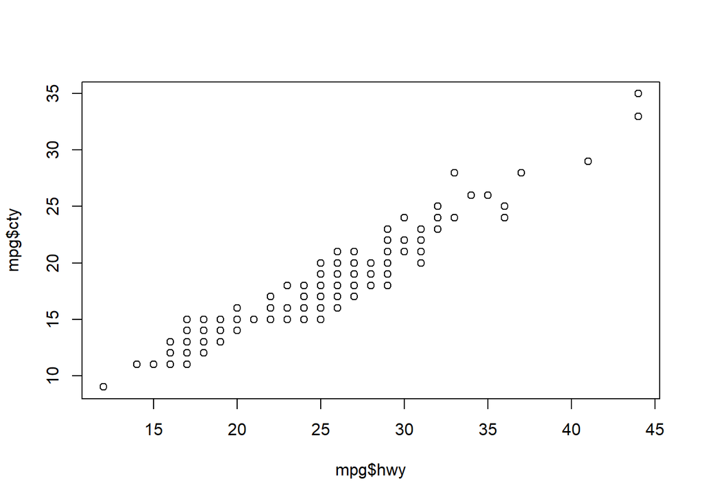

```r
plot(mpg$hwy, mpg$cty)
```

4. Are cars in 2008 more fuel efficient than cars in 1999? Use graphs *and* summary statistics to answer this question.

Start by extracting the data for 1999 cars into a data frame `cars1999` and the data for 2008 cars into a data frame `cars2008`. Then compare the summary statistics for the `hwy` and `cty` mpg for each data frame.

The summary statistics show only slight differences between fuel efficiency, so we look at boxplots comparing the city and highway mpg for 1999 and 2008 cars. The boxplot for cars’ city mpg shows nearly no difference between 1999 cars and 2008 cars. It does show the presence of outliers in the 1999 cars which could account for the higher mean city mpg of 1999 cars compared to the mean city mpg of 2008 cars. The highway mpg boxplot also shows outliers in the 1999 cars. It also shows a more condensed 3rd quartile group for 1999 cars than for 2008 cars.

Overall, the summary statistics and boxplots do not show a drastic difference between the fuel efficiency of cars from 1999 and cars from 2008.

```r
cars1999 = mpg[mpg$year == 1999, ]
cars2008 = mpg[mpg$year == 2008, ]
carsCompare = mpg[mpg$year == 1999 | 2008, ]
summary(cars1999)
```

```
##  manufacturer          model               displ            year
##  Length:117         Length:117         Min.   :1.600   Min.   :1999
##  Class :character   Class :character   1st Qu.:2.200   1st Qu.:1999
##  Mode  :character   Mode  :character   Median :3.000   Median :1999
##                                        Mean   :3.281   Mean   :1999
##                                        3rd Qu.:4.000   3rd Qu.:1999
##                                        Max.   :6.500   Max.   :1999
##       cyl           trans               drv                 cty
##  Min.   :4.000   Length:117         Length:117         Min.   :11.00
##  1st Qu.:4.000   Class :character   Class :character   1st Qu.:14.00
##  Median :6.000   Mode  :character   Mode  :character   Median :17.00
##  Mean   :5.692                                         Mean   :17.02
##  3rd Qu.:6.000                                         3rd Qu.:19.00
##  Max.   :8.000                                         Max.   :35.00
##       hwy             fl               class
##  Min.   :15.00   Length:117         Length:117
##  1st Qu.:17.00   Class :character   Class :character
##  Median :25.00   Mode  :character   Mode  :character
##  Mean   :23.43
##  3rd Qu.:26.00
##  Max.   :44.00
```

```r
summary(cars2008)
```

```
##  manufacturer          model               displ            year
##  Length:117         Length:117         Min.   :1.800   Min.   :2008
##  Class :character   Class :character   1st Qu.:2.500   1st Qu.:2008
##  Mode  :character   Mode  :character   Median :3.600   Median :2008
##                                        Mean   :3.662   Mean   :2008
##                                        3rd Qu.:4.700   3rd Qu.:2008
##                                        Max.   :7.000   Max.   :2008
##       cyl           trans               drv                 cty
##  Min.   :4.000   Length:117         Length:117         Min.   : 9.0
##  1st Qu.:4.000   Class :character   Class :character   1st Qu.:13.0
##  Median :6.000   Mode  :character   Mode  :character   Median :17.0
##  Mean   :6.085                                         Mean   :16.7
##  3rd Qu.:8.000                                         3rd Qu.:20.0
##  Max.   :8.000                                         Max.   :28.0
##       hwy             fl               class
##  Min.   :12.00   Length:117         Length:117
##  1st Qu.:18.00   Class :character   Class :character
##  Median :24.00   Mode  :character   Mode  :character
##  Mean   :23.45
##  3rd Qu.:28.00
##  Max.   :37.00
```

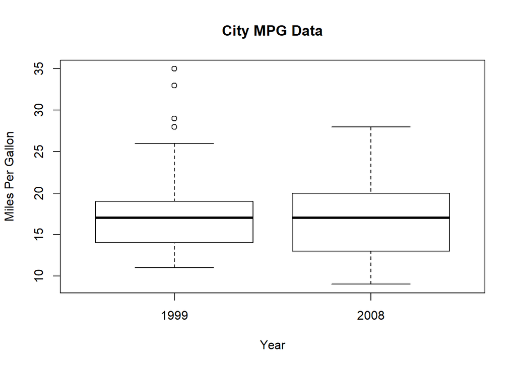

```r
boxplot(cty~year,data=carsCompare, main="City MPG Data",
   xlab="Year", ylab="Miles Per Gallon")
```

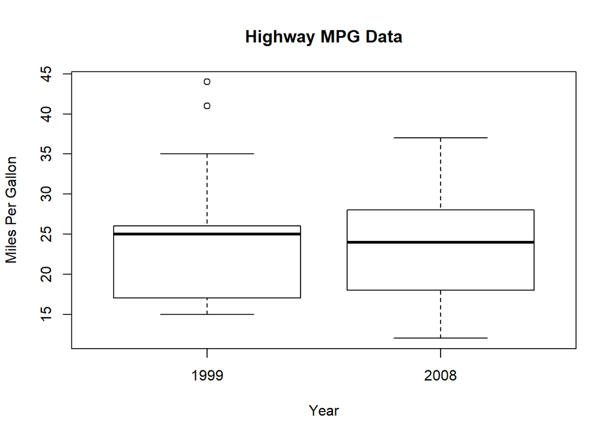

```r
boxplot(hwy~year,data=carsCompare, main="Highway MPG Data",
   xlab="Year", ylab="Miles Per Gallon")
```